# SCHOOL Development Team

Acknowledgments of those involved in the production of the TOPSTSCHOOL Modules

# SCHOOL TOPS Team Members

# SCHOOL Subject Matter Experts (SMEs)

##### Pedagogy

**Tom M. Parris**  
[iSciences](https://www.isciences.com/) President

##### Module 1: Water

**Tom M. Parris**  
President at [iSciences](https://www.isciences.com/) **Laureline M. Josset**  
Associate Research Scientist at [Columbia Water Center](https://water.columbia.edu/)

# SCHOOL Development Team

**Deborah Balk**  
Director at the [CUNY Institute for Demographic Research](https://www.cuny.edu/about/centers-and-institutes/demographic-research/) and professor at [Baruch College](https://www.baruch.cuny.edu/)

**Josh Brinks**  
Research Scientist at [iSciences](https://www.isciences.com/)

**Christina Alexia Deodatis**  
Research Staff Assistant at [CIESIN, Columbia Climate School](https://www.ciesin.columbia.edu/index.html)

**Hasim Engin**  
Geographic Information Specialist at [CIESIN, Columbia Climate School](https://www.ciesin.columbia.edu/index.html)

**Camilla Green**  
Research Staff Assistant at [CIESIN, Columbia Climate School](https://www.ciesin.columbia.edu/index.html)

**Kytt MacManus**  
Assistant Systems Engineer at NASA Socioeconomic Data and Applications Center $($[SEDAC](https://sedac.ciesin.columbia.edu/)$)$ and GIS Developer at [CIESIN, Columbia Climate School](https://www.ciesin.columbia.edu/index.html)

**Juan Fernando Martinez**  
Senior Research Staff Assistant at [CIESIN, Columbia Climate School](https://www.ciesin.columbia.edu/index.html)

**Josie Morkin**  
Research Staff Assistant at [CIESIN, Columbia Climate School](https://www.ciesin.columbia.edu/index.html)

**Tom M. Parris**  
President at [iSciences](https://www.isciences.com/)

**Linda Pistolesi**  
Senior Geographic Information Specialist at [CIESIN, Columbia Climate School](https://www.ciesin.columbia.edu/index.html)

**Sri Vinay**  
Deputy Manager & System Engineer at NASA Socioeconomic Data and Applications Center $($[SEDAC](https://sedac.ciesin.columbia.edu/)$)$ and Associate Director for IT at [CIESIN, Columbia Climate School](https://www.ciesin.columbia.edu/index.html)

**Greg Yetman**  
Associate Director for Geospatial Applications at [CIESIN, Columbia Climate School](https://www.ciesin.columbia.edu/index.html)

# SCHOOL Yearbook

### SMEs

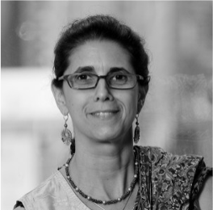

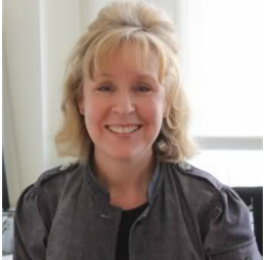

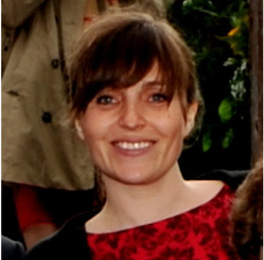

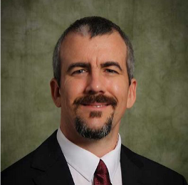

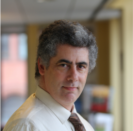

**Deborah Balk**

**Nancy Degnan**

**Laureline Josset**

**Ryan Meade**

**Thomas Parris**

CUNY Baruch CIDR

Columbia University

Columbia Water Center

SUNY Binghampton

iSciences

### Development Team

| **Navin Aade** | **Josh Brinks** | **Iris Cano** | **Christina Deodatis** | **Hasim Engin** |
| --- | --- | --- | --- | --- |
| Columbia Climate School | iSciences | CUNY Baruch | CIESIN | CIESIN |